# Report for Uniprot-Identified Tissue-Specific Proteins

Angela Yoder

2021-10-12

**The goals of this program are:**

1. Summarize the genes identified as tissue-specific by uniprot
1. Look at the criteria for tissue-specificity within uniprot
2. Run Ssec code with these genes
1. Uniprot-identified Tissue-Specific and exclusive to the tissues
2. Uniprot-identified Tissue-Specific, without excluding those not exclusive to the tissues
3. Determine the characteristics of those that are labeled as tissue-specific but are not exclusive to one tissue

Here we are restricting our protein-coding RNA-seq data to those genes that are labeled as “tissue-specific” on the uniprot database.We will calculate Ssec scores for those labeled as tissue-specific on uniprot, comparing secreted to non-secreted. These will be labeled as tissue-specific non-exclusive. Additionally, we will calculate these same scores for genes that are labeled tissue-specific AND are only found in the corresponding dataset (brain genes are not found in the liver dataset and vice versa). These will be labeled tissue-specific exclusive.

Below is a table of the number of genes in the labeled categories. We can see the sample size go down dramatically with the conditioning on tissue exclusivity. The first Ssec score analysis below will be using the Secreted TS Uniprot Exclusive brain and liver datasets (the last two rows below). The second Ssec score analysis will be using the Secreted TS Uniprot brain and liver datasets (the fifth and sixth rows).

Number of Genes

|  | x |
| --- | --- |
| TS Uniprot Brain | 1592 |
| TS Uniprot Liver | 1305 |
| TS Uniprot Exclusive Brain | 321 |
| TS Uniprot Exclusive Liver | 34 |
| Secreted TS Uniprot Brain | 168 |
| Secreted TS Uniprot Liver | 129 |
| Secreted TS Uniprot Exclusive Brain | 47 |
| Secreted TS Uniprot Exclusive Liver | 8 |

## Secreted TS Uniprot Exclusive

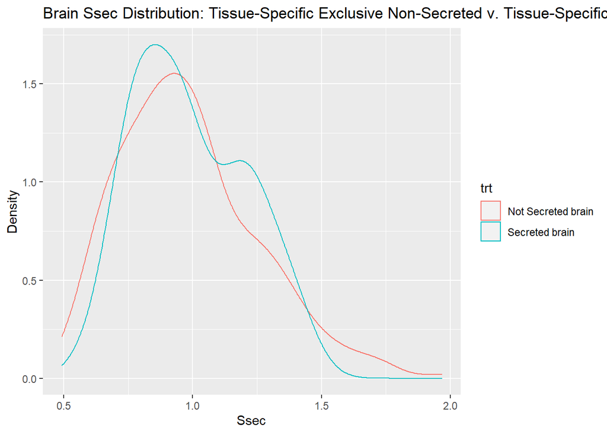

The following analysis is comparing the Ssec distribution between secreted and non-secreted genes that were coded as tissue-specific by Uniprot and determined to be exclusive to brain/liver by direct comparison. The Wilcoxon-Mann-Whitney test shows that neither brain nor liver had significant differences between secreted and non-secreted (brain = 0.6793315; liver = 0.5976391).

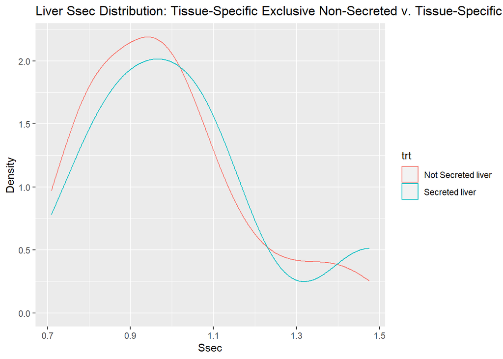

## Secreted TS Uniprot

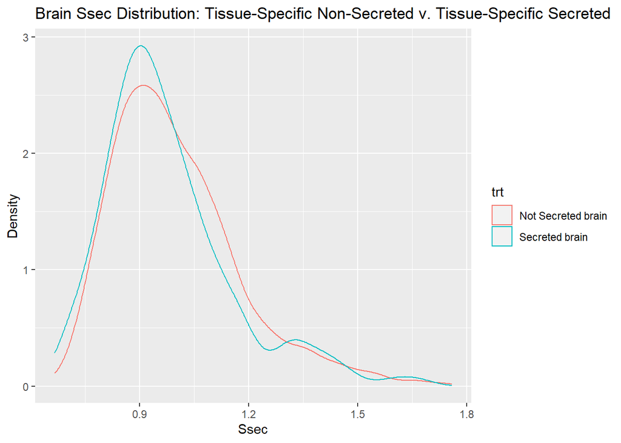

The following analysis is comparing the Ssec distribution between secreted and non-secreted genes that were coded as tissue-specific by Uniprot. This set excluded the extra step of determining exclusivity, so some genes may be shared between the two groups. The Wilcoxon-Mann-Whitney test shows a nearly significant p-value for brain (closest we have gotten so far: 0.0571151), but an non-significant p-value for liver (0.6659825).

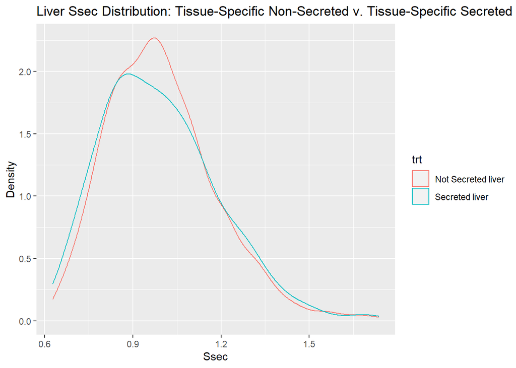

## Evaluating Non-Exclusive Tissue-Specific Datasets

It seems that in the Uniprot database, tissue-specificity does not indicate that a protein is only found in a single tissue, but rather there is SOME KIND of specificity in where it is found. For example, the following gene is noted as tissue-specific in Uniprot, but was found in the liver dataset:

ENSRNOG00000020889: not exclusive but tissue specific brain; “Minor constituent of the mineralized matrix of bone. Detected in calvaria, rib cartilage, liver, kidney, spleen, brain, lung, skeletal and heart muscle with highest expression in calvaria and approximately half the amount in kidney, liver and brain.”

The following genes were the top genes as selected by the Ssec scores for the brain dataset, but were also found in the liver dataset:

ENSRNOG00000003732: from top_brain; “Detected in brain (at protein level)” ENSRNOG00000023337: from top_brain; “Expressed in the dorsal root ganglia” ENSRNOG00000018962: from top_brain; “Expressed in the ventricle and atrium of adult rats. Also detected in the lung, kidney, liver, skeletal muscle, stomach and urinary bladder. Not detected in brain, colon, testis, spleen or thymus. Overexpressed in the ventricles in the case of hypertension and hypertrophy.” in the ensembl database, they say there is expression in brain with an expression score of 56.67, compared to 77.93 in the liver

The following graph compares average reads for genes that are tissue-specific and NOT exclusive to brain to those same genes in liver. If tissue-specific annotation from Uniprot is useful, brain should have more reads for these genes than liver, as shown in the graph. The Wilcoxon-Mann_Whitney test affirms this.

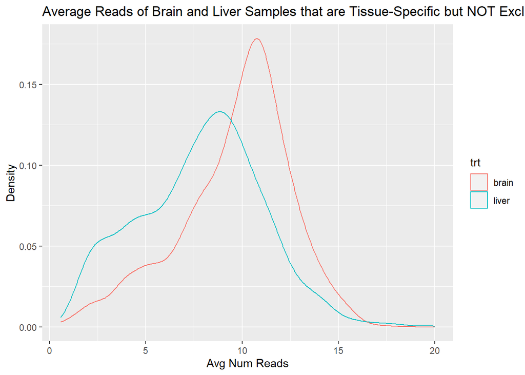

```
##
##  Asymptotic Wilcoxon-Mann-Whitney Test
##
## data:  val by trt (brain, liver)
## Z = 15.105, p-value < 2.2e-16
## alternative hypothesis: true mu is not equal to 0
```